# MSC_CW1_13172387_F_Neziri

###### (f) Suppose that we wish to predict gas mileage (mpg) on the basis of the other variables. Do your plots suggest that any of the other variables might be useful in predicting mpg? Justify your answer.

**Yes.** There seems to be a strong relationship between mpg and every other quantitative variable. See the graphs below for the relationship between each variable and mpg.

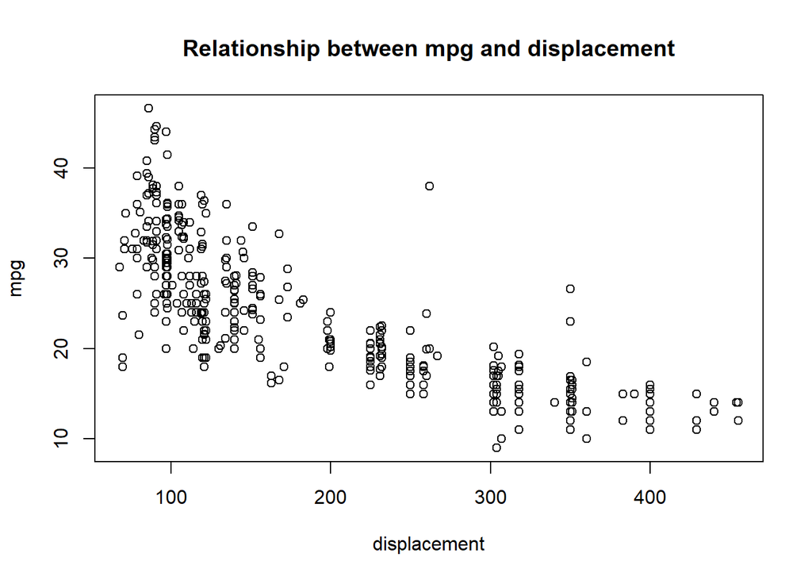

The larger the displacement of a car’s engine, the less miles per gallon the car achieves.

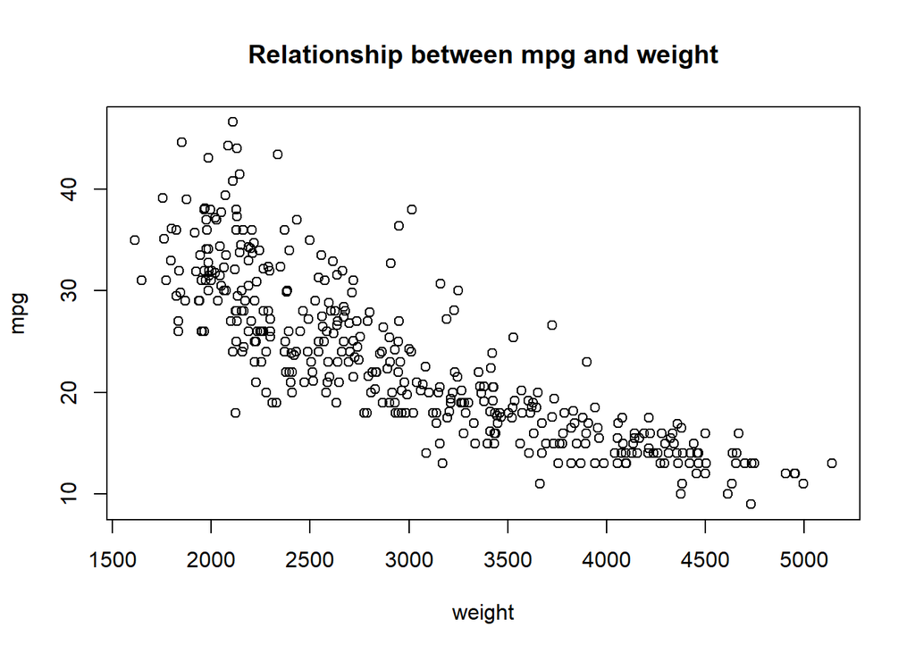

The heavier a car, the less miles per gallon it achieves.

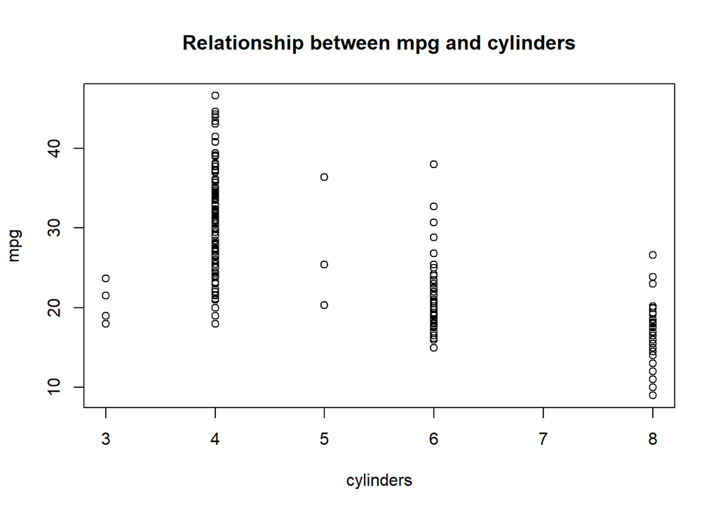

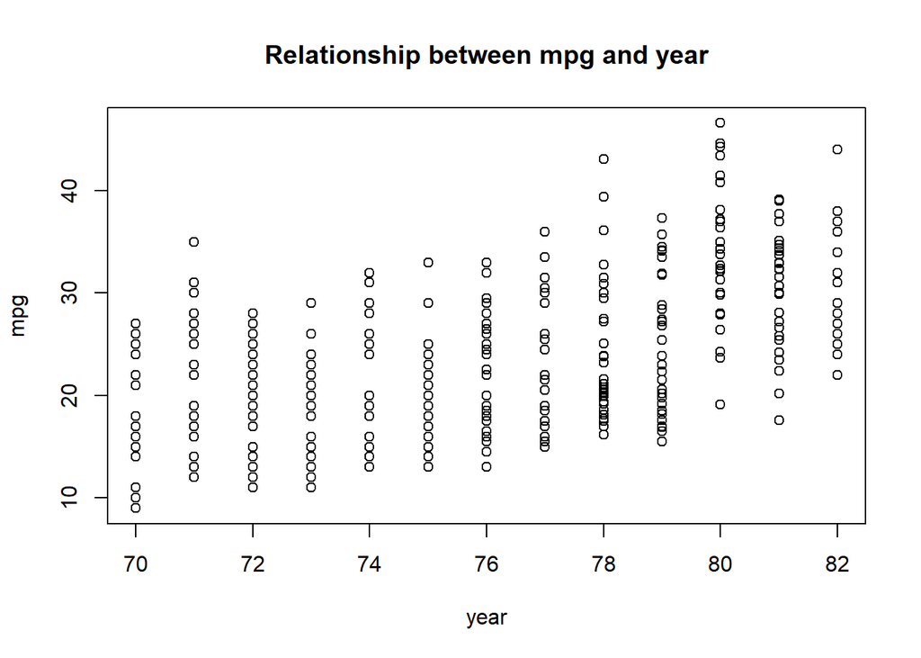

Cars generally achieve higher miles per gallon if they were built later (are newer).

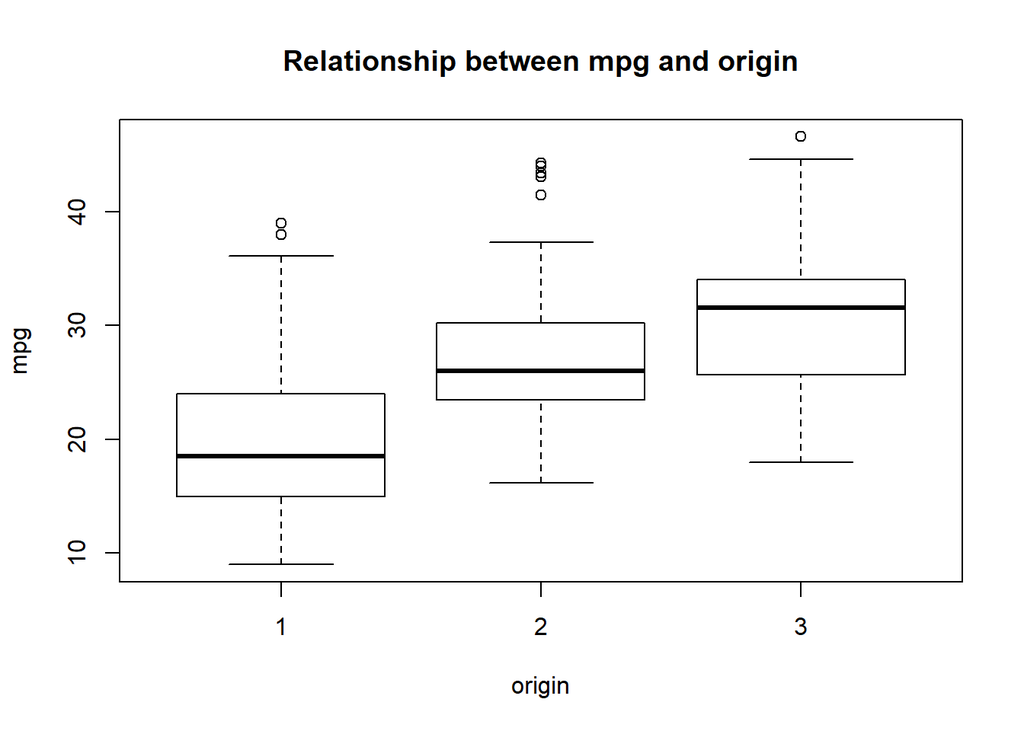

Cars with origin = 3 (from Japan), achieve higher miles per gallon than those with origin = 2 (from Europe), and both achieve higher miles per gallon than cars with origin = 1 (from the USA).

#### 4. Linear Regression

###### (a) Use the lm() function to perform a simple linear regression with mpg as the response and horsepower as the predictor. Use the summary() function to print the results. Comment on the output.

```
##
## Call:
## lm(formula = mpg ~ horsepower, data = Auto)
##
## Residuals:
##      Min       1Q   Median       3Q      Max
## -13.5710  -3.2592  -0.3435   2.7630  16.9240
##
## Coefficients:
##              Estimate Std. Error t value Pr(>|t|)
## (Intercept) 39.935861   0.717499   55.66   <2e-16 ***
## horsepower  -0.157845   0.006446  -24.49   <2e-16 ***
## ---
## Signif. codes:  0 '***' 0.001 '**' 0.01 '*' 0.05 '.' 0.1 ' ' 1
##
## Residual standard error: 4.906 on 390 degrees of freedom
## Multiple R-squared:  0.6059, Adjusted R-squared:  0.6049
## F-statistic: 599.7 on 1 and 390 DF,  p-value: < 2.2e-16
```

###### i. Is there a relationship between the predictor and the response?

**Yes.** The p-value is very small meaning we can reject the null hypothesis that there is no relationship between horsepower and mpg.

###### ii. How strong is the relationship between the predictor and the response?

**Fairly strong**. The R-squared value is 0.6059 which implies that 60.59% of the sample variation in mpg is explained by horsepower.

###### iii. Is the relationship between the predictor and the response positive or negative?

**Negative**. The coefficient for horsepower is -0.157845, meaning that for every additional horsepower a car’s engine has, the miles per gallon falls by 0.157845 miles.

###### iv. What is the predicted mpg associated with a horsepower of 89? What are the associated 99% conﬁdence and prediction intervals?

The predicted mpg associated with a horsepower of 89 is: 25.8876798

The associated 99% confidence and prediction intervals or predicted mpg with a horsepower of 89 are as follows:

99% Confidence intervals:

```
##        fit      lwr      upr
## 1 25.88768 25.19633 26.57903
```

99% Prediction intervals:

```
##        fit      lwr      upr
## 1 25.88768 13.17035 38.60501
```

###### (b) Plot the response and the predictor. Use the abline() function to display the least squares regression line.

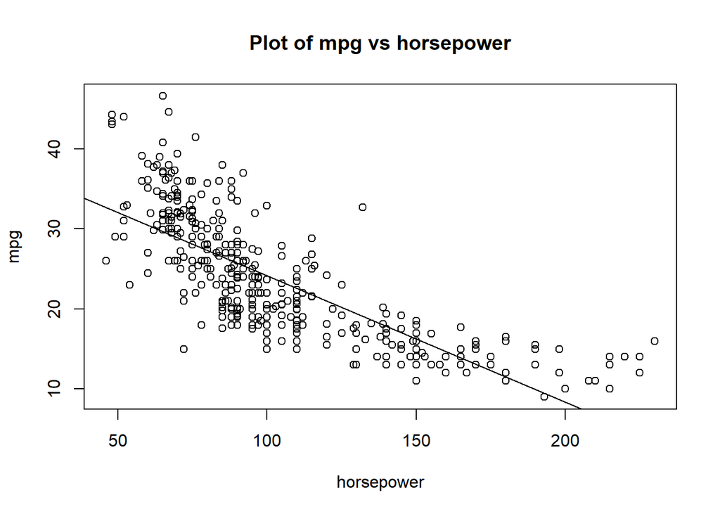

###### (c) Plot the 99% conﬁdence interval and prediction interval in the same plot as (b) using different colours and legends.

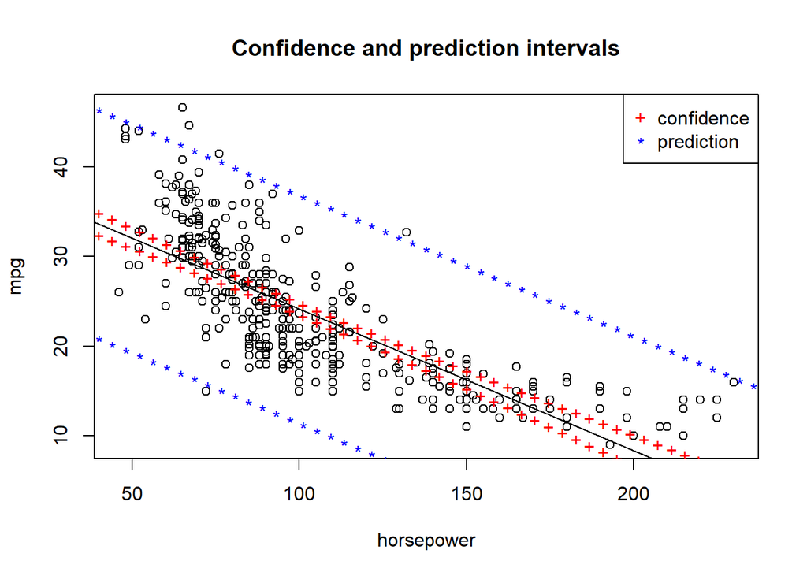

#### 5. Logistic Regression

A recent study has shown that the accurate prediction of the oﬃce room occupancy leads to potential energy savings of 30%. In this question, you are required to build logistic regression models by using diﬀerent environmental measurements as features,tra such as temperature, humidity, light, CO2 and humidity ratio, to predict the oﬃce room occupancy. The provided training dataset consists of 2,000 samples, whilst the testing dataset consists of 300 samples.

###### (a) Load the training and testing datasets from corresponding ﬁles, and display the statistics about different features in the training dataset.

First need to convert Occupancy to a factor as it should be treated as a categorical variable. In my answers, Occupancy = 0 means unoccupied, and Occupancy = 1 means occupied.

```r
training$Occupancy <- factor(training$Occupancy)
testing$Occupancy <- factor(testing$Occupancy)
```

Statistics for the training data:

```
##   Temperature       Humidity         Light            CO2
##  Min.   :20.10   Min.   :18.96   Min.   :  0.0   Min.   : 426.0
##  1st Qu.:20.89   1st Qu.:21.82   1st Qu.:  0.0   1st Qu.: 448.0
##  Median :21.20   Median :25.00   Median :  0.0   Median : 485.5
##  Mean   :21.42   Mean   :24.22   Mean   :144.7   Mean   : 634.6
##  3rd Qu.:22.10   3rd Qu.:26.29   3rd Qu.:433.0   3rd Qu.: 845.8
##  Max.   :23.18   Max.   :28.50   Max.   :744.0   Max.   :1139.0
##  HumidityRatio      Occupancy
##  Min.   :0.002824   0:1445
##  1st Qu.:0.003375   1: 555
##  Median :0.003905
##  Mean   :0.003836
##  3rd Qu.:0.004343
##  Max.   :0.004817
```

###### (b) Build a logistic regression model by only using the Temperature feature to predict the room occu;pancy. Display the confusion matrix and the predictive accuracy obtained on the testing dataset.

The confusion matrix when using Temperature to predict room occupancy:

```
##           truth
## prediction   0   1
##          0 182  39
##          1  58  21
```

The predictive accuracy of the logistic regression model, when using Temperature to predict room occupancy, is: 0.6766667

###### (c) Build a logistic regression model by only using the Humidity feature to predict the room occupancy. Display the confusion matrix and the predictive accuracy obtained on the testing dataset.

The confusion matrix when using Humidity to predict room occupancy:

```
##           truth
## prediction   0   1
##          0 133  22
##          1 107  38
```

The predictive accuracy of the logistic regression model, when using Humidity to predict room occupancy, is: 0.57

###### (d) Build a logistic regression model by using all features to predict the room occupancy. Display the confusion matrix and the predictive accuracy obtained on the testing dataset.

The confusion matrix when using all variables to predict room occupancy:

```
##           truth
## prediction   0   1
##          0 184  13
##          1  56  47
```

The predictive accuracy of the logistic regression model, when using all variables to predict room occupancy, is: 0.77

###### (e) Compare the predictive performance of three different models by drawing ROC curves and calculating the AUROC values. Discuss the comparison results.

The AUROC value of the logistic regression model for Temperature on Occupancy is: 0.7527431

The AUROC value of the logistic regression model for Humidity on Occupancy is: 0.6038194

The AUROC value of the logistic regression model for all variables on Occupancy is: 0.7977778

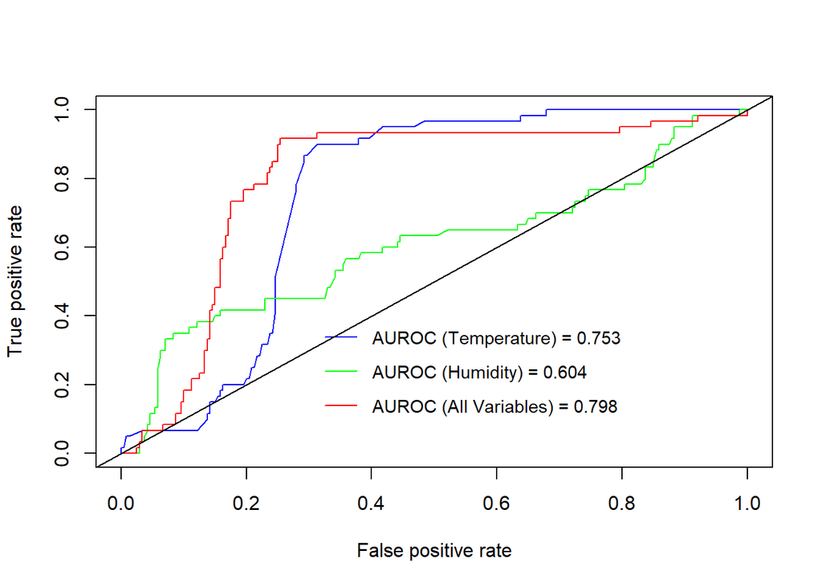

The closer the ROC curve to the upper left corner, the higher the classification accuracy of model, and the greater the area under the curve (AUROC). We can see from the AUROC values calculated, and the ROC curves illustrated, that the model which uses all variable to predict room occupancy (the red line) obtains the best accuracy amongst the three models.

#### 6. Resampling Methods

We are trying to learn regression parameters for a dataset which we know was generated from a polynomial of a certain degree, but we do not know what this degree is.

Assume the data was actually generated from a polynomial of degree 3 with some added noise, that is

y = β0 +β1x+β2x2 +β3x3 +ε, ε ∼ N(0,1)

For training we have 400 (x,y)-pairs and for testing we are using an additional set of 400 (x,y)-pairs. Since we do not know the degree of the polynomial we learn two models from the data:

- Model A learns parameters for a polynomial of degree 2, and
- Model B learns parameters for a polynomial of degree 4.

###### (a) Which of these two models is likely to ﬁt the test data better? Justify your answer.

**Polynomial of degree 4.**

The original model is a polynomial of degree 3 and, as we have enough training data, the model we learn for a polynomial of degree 4 will likely fit a very small coefficient for x4.

So, despite model B being a model of polynomial degree 4, it should behave in a very similar way to a polynomial of degree 3, leading to a better fit to the data.

###### (b) Generate the simulated data set as follows:

set.seed(235)

x = 12 + rnorm(400)

y = 1 - x + 4*x^2 - 5*x^3 + rnorm(400)

Create a scatterplot of X against Y. Comment on what you ﬁnd.

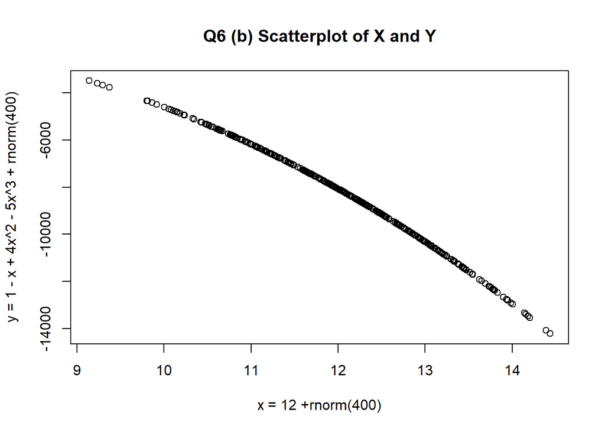

There appears to be a non-linear negative relationship between x and y.

###### (c) Set the seed to be 34, and then compute the LOOCV and 10-fold CV errors that result from ﬁtting the following models using least squares:

1. Y = β0 +β1X +β2X2 +ε
2. Y = β0 +β1X +β2X2 +β3X3 +β4X4 +ε.

Note you may ﬁnd it helpful to use the data.frame() function to create a single data set containing both X and Y.

###### i. Y = β0 +β1X +β2X2 +ε

The LOOCV error is:

```
## [1] 100.2671 100.2571
```

The 10-fold CV error is:

```
## [1] 98.05820 97.76747
```

###### ii. Y = β0 +β1X +β2X2 +β3X3 +β4X4 +ε

The LOOCV error is:

```
## [1] 1.017966 1.017931
```

The 10-fold CV error is:

```
## [1] 1.018737 1.017240
```

###### (d) Repeat (c) using random seed 68, and report your results. Are your results the same as what you got in (c)? Why?

###### i. Y = β0 +β1X +β2X2 +ε

The LOOCV error is:

```
## [1] 100.2671 100.2571
```

The 10-fold CV error is:

```
## [1] 107.8738 106.9886
```

###### ii. Y = β0 +β1X +β2X2 +β3X3 +β4X4 +ε

The LOOCV error is:

```
## [1] 1.017966 1.017931
```

The 10-fold CV error is:

```
## [1] 1.024362 1.022544
```

The LOOCV errors are the same with different seeds since LOOCV evaluates n folds of a single observation.

The data is split into the validation set - of size 1 - and the training set - of size n-1. We fit the model using the training set and then validate using the validation set, and repeat this process n times. Because we split based on 1 observation each time, repeating LOOCV multiple times will always yield the same result.

The 10-fold CV errors are different with different seeds as we use k-folds (in this instance k=10).

With 10-fold CV we divide the data in 10 different parts, with the observations we used as our different seeds - 34 and 68 - falling into different folds. We then remove the first part, fit the model on the remaining k-1 parts, and see how good the predictions are on the left out part, and repeat this k different times taking out a different part each time

###### (e) Which of the models in (c) had the smallest LOOCV and 10-fold CV error? Is this what you expected? Explain your answer.

The polynomial of degree 4 has the smaller LOOCV and 10-fold CV errors. Yes, this is what we expected.

###### (f) Comment on the coefficient estimates and the statistical signiﬁcance of the coeffcient estimates that results from ﬁtting the preferred model in (a).

```
##
## Call:
## glm(formula = y ~ poly(x, 4), data = Data.Q6)
##
## Deviance Residuals:
##     Min       1Q   Median       3Q      Max
## -2.9184  -0.5951   0.0207   0.6436   3.3437
##
## Coefficients:
##               Estimate Std. Error    t value Pr(>|t|)
## (Intercept) -8.406e+03  5.008e-02 -1.678e+05   <2e-16 ***
## poly(x, 4)1 -4.207e+04  1.002e+00 -4.200e+04   <2e-16 ***
## poly(x, 4)2 -4.659e+03  1.002e+00 -4.651e+03   <2e-16 ***
## poly(x, 4)3 -1.914e+02  1.002e+00 -1.911e+02   <2e-16 ***
## poly(x, 4)4  2.331e-03  1.002e+00  2.000e-03    0.998
## ---
## Signif. codes:  0 '***' 0.001 '**' 0.01 '*' 0.05 '.' 0.1 ' ' 1
##
## (Dispersion parameter for gaussian family taken to be 1.003333)
##
##     Null deviance: 1.7914e+09  on 399  degrees of freedom
## Residual deviance: 3.9632e+02  on 395  degrees of freedom
## AIC: 1143.5
##
## Number of Fisher Scoring iterations: 2
```

We see that the coefficients for x1, x2, and x3, have very small p-values and are therefore statiscally significant. The coefficients get smaller as the degree of x gets larger, and each coefficient is negative - highlighting the negative relatinship between x and y which is what we expected from the scatterplot in (b).

The coefficent for x4 has a large p-value and is therefore statiscally insignificant, which backs up my answer in (a) - the model with polynomial 4 behaves in a very similar way to a polynomial of degree 3, leading to a better fit to the data.

###### (g) Fit a cubic model and compute its LOOCV error, 10-fold CV error under seed 34, and comment on the coeffcient estimates and the statistical signiﬁcance of the coeffcient estimates. Compare the LOOCV and 10-fold CV error with the preferred model in (a).

Y = β0 +β1X +β2X2 + β3x3 +ε

The LOOCV error is:

```
## [1] 1.010868 1.010843
```

The 10-fold CV error is:

```
## [1] 1.011413 1.010312
```

The LOOCV and 10-fold CV errors are smaller in the cubic model as opposed to the model with polynomial of degree 4 which is what we expected as the original model was also a cubic model.

```
##
## Call:
## glm(formula = y ~ poly(x, 3), data = Data.Q6)
##
## Deviance Residuals:
##     Min       1Q   Median       3Q      Max
## -2.9184  -0.5950   0.0207   0.6436   3.3436
##
## Coefficients:
##               Estimate Std. Error   t value Pr(>|t|)
## (Intercept) -8.406e+03  5.002e-02 -168056.7   <2e-16 ***
## poly(x, 3)1 -4.207e+04  1.000e+00  -42050.4   <2e-16 ***
## poly(x, 3)2 -4.659e+03  1.000e+00   -4657.2   <2e-16 ***
## poly(x, 3)3 -1.914e+02  1.000e+00    -191.3   <2e-16 ***
## ---
## Signif. codes:  0 '***' 0.001 '**' 0.01 '*' 0.05 '.' 0.1 ' ' 1
##
## (Dispersion parameter for gaussian family taken to be 1.0008)
##
##     Null deviance: 1.7914e+09  on 399  degrees of freedom
## Residual deviance: 3.9632e+02  on 396  degrees of freedom
## AIC: 1141.5
##
## Number of Fisher Scoring iterations: 2
```

We see that the coefficients for x1, x2, and x3, have very small p-values and are therefore statiscally significant. The coefficients get smaller as the degree of x gets larger, and each coefficient is negative - highlightin the negative relatinship between x and y which is what we expected from the scatterplot in (b).